# 1. Read Data

```r
data(longley)
y <- as.matrix(longley$Employed)
df <- longley[, -which(names(longley) == "Employed")]
X <- as.matrix(cbind(1, df))  # Add intercept (ones) as the first column
X
```

```
##      1 GNP.deflator     GNP Unemployed Armed.Forces Population Year
## 1947 1         83.0 234.289      235.6        159.0    107.608 1947
## 1948 1         88.5 259.426      232.5        145.6    108.632 1948
## 1949 1         88.2 258.054      368.2        161.6    109.773 1949
## 1950 1         89.5 284.599      335.1        165.0    110.929 1950
## 1951 1         96.2 328.975      209.9        309.9    112.075 1951
## 1952 1         98.1 346.999      193.2        359.4    113.270 1952
## 1953 1         99.0 365.385      187.0        354.7    115.094 1953
## 1954 1        100.0 363.112      357.8        335.0    116.219 1954
## 1955 1        101.2 397.469      290.4        304.8    117.388 1955
## 1956 1        104.6 419.180      282.2        285.7    118.734 1956
## 1957 1        108.4 442.769      293.6        279.8    120.445 1957
## 1958 1        110.8 444.546      468.1        263.7    121.950 1958
## 1959 1        112.6 482.704      381.3        255.2    123.366 1959
## 1960 1        114.2 502.601      393.1        251.4    125.368 1960
## 1961 1        115.7 518.173      480.6        257.2    127.852 1961
## 1962 1        116.9 554.894      400.7        282.7    130.081 1962
```

# 2. Compute Models and Time Consumed

#### LU Decomposition

```r
start_time <- Sys.time()
beta_hat <- solve(t(X) %*% X) %*% t(X) %*% y  # Compute beta_hat
residuals <- y - X %*% beta_hat
n <- nrow(X)
p <- ncol(X)
sigma_hat_sq <- t(residuals) %*% residuals / (n - p)  # Compute sigma_hat_sq
var_beta_hat <- as.numeric(sigma_hat_sq) * solve(t(X) %*% X)  # Compute variance of beta_hat
se_beta_hat <- sqrt(diag(var_beta_hat))  # Compute SE of beta_hat
end_time <- Sys.time()
time_GE_LU <- end_time - start_time
time_GE_LU
```

```
## Time difference of 0.06166005 secs
```

#### Cholesky decomposition

```r
start_time <- Sys.time()
XtX <- t(X) %*% X
XtX_inv <- chol2inv(chol(XtX))
beta_hat_chol <- XtX_inv %*% t(X) %*% y
residuals_chol <- y - X %*% beta_hat_chol
sigma_hat_sq_chol <- t(residuals_chol) %*% residuals_chol / (n - p)
var_beta_hat_chol <- as.numeric(sigma_hat_sq_chol) * XtX_inv
se_beta_hat_chol <- sqrt(diag(var_beta_hat_chol))
end_time <- Sys.time()
time_Cholesky <- end_time - start_time
time_Cholesky
```

```
## Time difference of 0.01341796 secs
```

#### QR decomposition

```r
start_time <- Sys.time()
qr_decomp <- qr(X)  # QR decomposition of X
R_inv <- solve(qr.R(qr_decomp))  # Inverse of R
Q <- qr.Q(qr_decomp)  # Q matrix

beta_hat_qr <- R_inv %*% t(Q) %*% y  # Compute beta_hat

residuals_qr <- y - X %*% beta_hat_qr
sigma_hat_sq_qr <- t(residuals_qr) %*% residuals_qr / (n - p)  # Compute sigma_hat_sq

var_beta_hat_qr <- as.numeric(sigma_hat_sq_qr) * R_inv %*% t(R_inv)  # Compute variance of beta_hat
se_beta_hat_qr <- sqrt(diag(var_beta_hat_qr))  # Compute SE of beta_hat
end_time <- Sys.time()
time_QR <- end_time - start_time
time_QR
```

```
## Time difference of 0.01788592 secs
```

#### Check the results

```r
model <- lm(Employed ~ ., data = longley)
summary(model)
```

```
##
## Call:
## lm(formula = Employed ~ ., data = longley)
##
## Residuals:
##      Min       1Q   Median       3Q      Max
## -0.41011 -0.15767 -0.02816  0.10155  0.45539
##
## Coefficients:
##                Estimate Std. Error t value Pr(>|t|)
## (Intercept)  -3.482e+03  8.904e+02  -3.911 0.003560 **
## GNP.deflator  1.506e-02  8.492e-02   0.177 0.863141
## GNP          -3.582e-02  3.349e-02  -1.070 0.312681
## Unemployed   -2.020e-02  4.884e-03  -4.136 0.002535 **
## Armed.Forces -1.033e-02  2.143e-03  -4.822 0.000944 ***
## Population   -5.110e-02  2.261e-01  -0.226 0.826212
## Year          1.829e+00  4.555e-01   4.016 0.003037 **
## ---
## Signif. codes:  0 '***' 0.001 '**' 0.01 '*' 0.05 '.' 0.1 ' ' 1
##
## Residual standard error: 0.3049 on 9 degrees of freedom
## Multiple R-squared:  0.9955, Adjusted R-squared:  0.9925
## F-statistic: 330.3 on 6 and 9 DF,  p-value: 4.984e-10
```

```r
beta_hat
```

```
##                       [,1]
## 1            -3.482259e+03
## GNP.deflator  1.506187e-02
## GNP          -3.581918e-02
## Unemployed   -2.020230e-02
## Armed.Forces -1.033227e-02
## Population   -5.110411e-02
## Year          1.829151e+00
```

```r
beta_hat_chol
```

```
##               [,1]
## [1,] -3.482259e+03
## [2,]  1.506187e-02
## [3,] -3.581918e-02
## [4,] -2.020230e-02
## [5,] -1.033227e-02
## [6,] -5.110411e-02
## [7,]  1.829151e+00
```

```r
beta_hat_qr
```

```
##                       [,1]
## 1            -3.482259e+03
## GNP.deflator  1.506187e-02
## GNP          -3.581918e-02
## Unemployed   -2.020230e-02
## Armed.Forces -1.033227e-02
## Population   -5.110411e-02
## Year          1.829151e+00
```

# 3. Prove The Ridge Solotion

$J(\beta) = (1/2)||y-X\beta||^2 + (λ/2)||\beta||^2$

$\frac {\partial J(B)}{\partial \beta} = -X^T(y-X \beta) + \lambda \beta = 0$

$-X^Ty+X^TX \beta + \lambda \beta = 0$

$(X^TX + \lambda I) \beta = X^T y$

$\hat{\beta} = (X^TX + \lambda I)^{-1} X ^Ty$

# 4. Plot 2-norm of Ridge Function

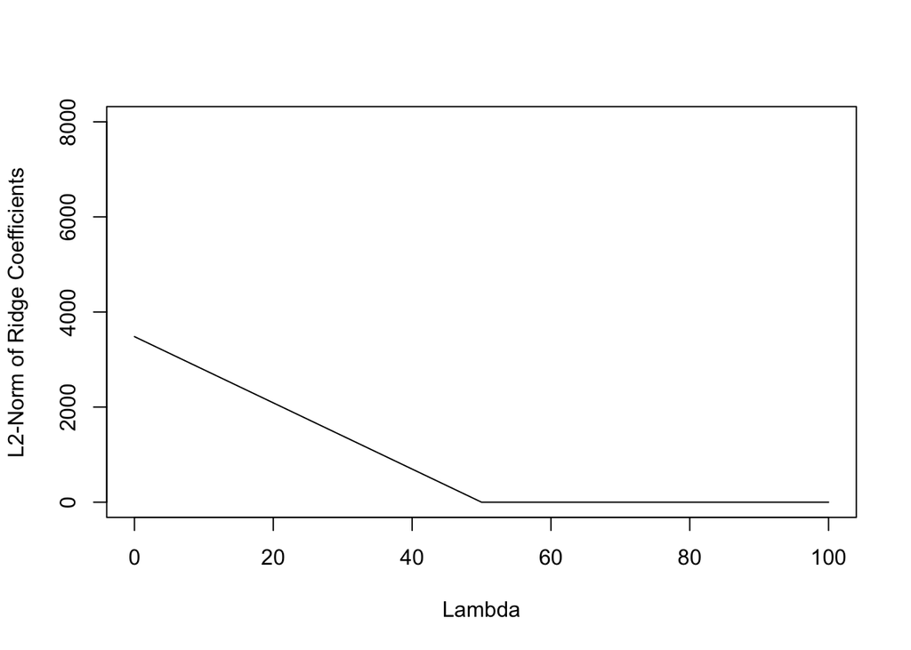

```r
lambda_values <- seq(0, 100, by = 50)
norms <- numeric(length(lambda_values))
for (i in seq_along(lambda_values)) {
  lambda <- lambda_values[i]
  beta_hat_ridge <- solve(t(X) %*% X + lambda * diag(p), t(X) %*% y)
  norms[i] <- sqrt(sum(beta_hat_ridge^2))
}
plot(lambda_values, norms, type = "l", xlab = "Lambda", ylab = "L2-Norm of Ridge Coefficients", ylim = c(0,8000))
```

# Using Parallel Computing

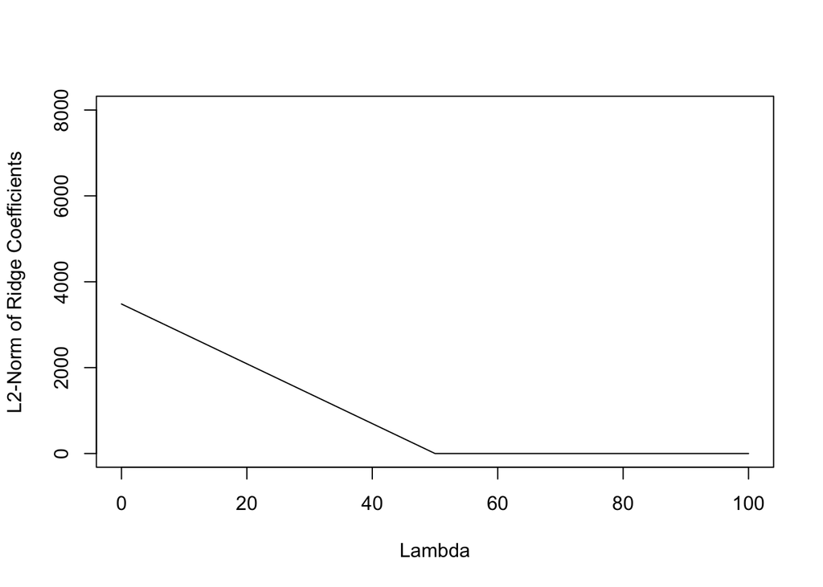

```r
# load the parallel package
library(parallel)

lambda_values <- seq(0, 100, by = 50)
p <- ncol(X)

# create a function to calculate beta_hat_ridge and its norm
calc_norm <- function(lambda) {
  beta_hat_ridge <- solve(t(X) %*% X + lambda * diag(p), t(X) %*% y)
  norm <- sqrt(sum(beta_hat_ridge^2))
  return(norm)
}

# use mclapply to calculate norms in parallel
norms <- mclapply(lambda_values, calc_norm, mc.cores = detectCores())

# since mclapply returns a list, unlist norms to a numeric vector
norms <- unlist(norms)

# plot the results
plot(lambda_values, norms, type = "l", xlab = "Lambda", ylab = "L2-Norm of Ridge Coefficients", ylim = c(0,8000))
```

# Find out which method is the lm() function in R is using? And which algorithm is being used?

QR decomposition is the method that lm() function in R is using.

QR algorithm factor a matrix into a product of an orthogonal matrix Q and a upper triangular matrix R, and use them to solve the linear equation,

$X \beta = y$

$R \beta = Q^Ty$

, by solving the second equation, we found that it’s easier to compute than the first one.

But it’s not always this case, R actually will choose the method that will depends on the circumstance. Sometimes, SVD method will be used to approach numeric stability, but it’s more computationally expensive.